# MatthewSmith_Final

## 2.

What proportion of public schools reported vaccination data?

```r
library(tidyverse)

allreports <- as.data.frame(allSchoolsReportStatus)

allreports_public <- allreports %>%
  filter(.$pubpriv == "PUBLIC")

public_Y_perc <- length(allreports_public$reported[allreports_public$reported == "Y"]) / length(allreports_public$reported)
public_N_perc <- length(allreports_public$reported[allreports_public$reported == "N"]) / length(allreports_public$reported)

public_Y_perc
```

```
## [1] 0.97418
```

```r
public_N_perc
```

```
## [1] 0.02581996
```

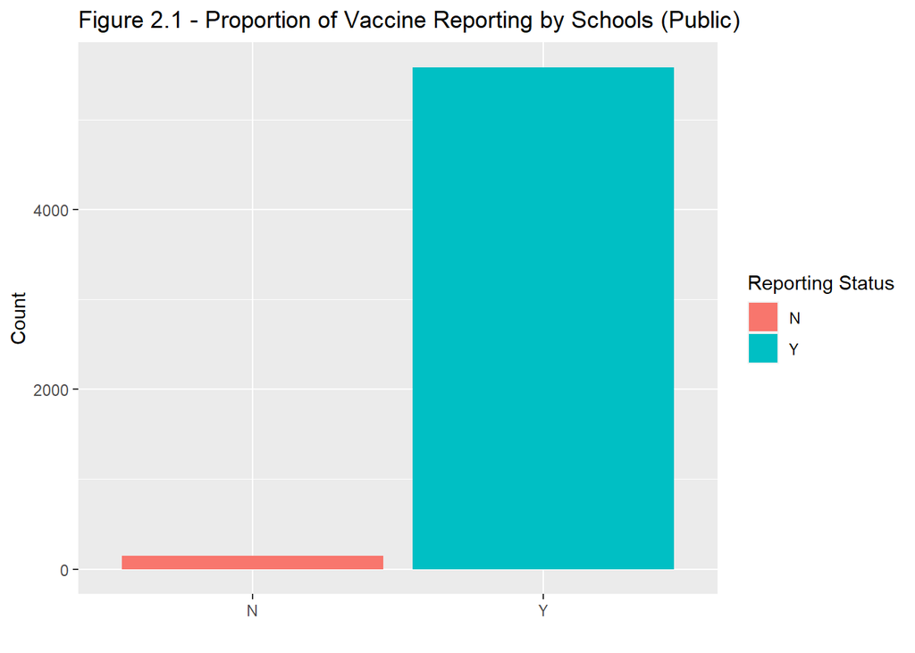

```r
ggplot(allreports_public, aes(x = as.factor(allreports_public$reported), fill = allreports_public$reported)) +
  geom_bar() +
  scale_fill_discrete(name = "Reporting Status") +
  xlab("") +
  ylab("Count") +
  ggtitle("Figure 2.1 - Proportion of Vaccine Reporting by Schools (Public)")
```

```r
# Approximately 97.4% of public schools reported vaccination data
```

What proportion of private schools reported vaccination data?

```r
allreports <- as.data.frame(allSchoolsReportStatus)

allreports_private <- allreports %>%
  filter(.$pubpriv == "PRIVATE")

private_Y_perc <- length(allreports_private$reported[allreports_private$reported == "Y"]) / length(allreports_private$reported)
private_N_perc <- length(allreports_private$reported[allreports_private$reported == "N"]) / length(allreports_private$reported)

private_Y_perc
```

```
## [1] 0.8471801
```

```r
private_N_perc
```

```
## [1] 0.1528199
```

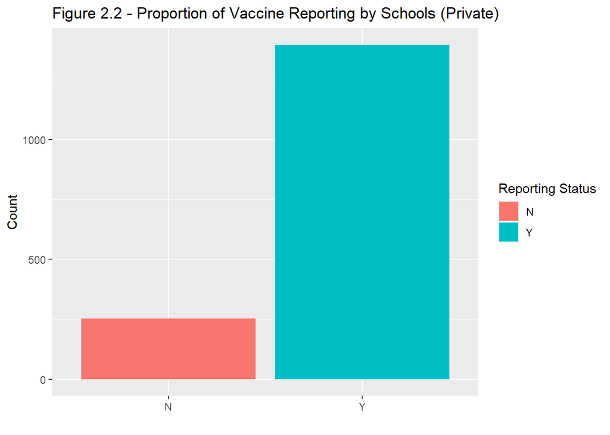

```r
ggplot(allreports_private, aes(x = as.factor(allreports_private$reported), fill = allreports_private$reported)) +
  geom_bar() +
  scale_fill_discrete(name = "Reporting Status") +
  xlab("") +
  ylab("Count") +
  ggtitle("Figure 2.2 - Proportion of Vaccine Reporting by Schools (Private)")
```

```r
# Approximately 84.7% of private schools reported vaccination data
```

Was there any credible difference in overall reporting proportions between public and private schools?

```r
library(plyr)
library(BEST)

allreports_coded <- allreports

allreports_coded$reported <- revalue(allreports_coded$reported, c("Y"=1))
allreports_coded$reported <- revalue(allreports_coded$reported, c("N"=0))

allreports_coded_public <- allreports_coded %>%
  filter(.$pubpriv == "PUBLIC")

allreports_coded_private <- allreports_coded %>%
  filter(.$pubpriv == "PRIVATE")

t.test(as.numeric(allreports_coded_public$reported), as.numeric(allreports_coded_private$reported))
```

```
##
##  Welch Two Sample t-test
##
## data:  as.numeric(allreports_coded_public$reported) and as.numeric(allreports_coded_private$reported)
## t = 13.944, df = 1835.6, p-value < 2.2e-16
## alternative hypothesis: true difference in means is not equal to 0
## 95 percent confidence interval:
##  0.1091376 0.1448623
## sample estimates:
## mean of x mean of y
## 0.9741800 0.8471801
```

```r
# From the t-test results above (comparing the Y/N results of the public/private schools), we can reject the null hypothesis (the difference in reporting between the two types of schools is statistically significant/not zero); t = 13.944; p < 0.001.
```

## 3.

What are 2013 vaccination rates for individual vaccines (i.e., DOT, Polio, MMR, and HepB) in California public schools? How do these rates for individual vaccines in California districts compare with overall US vaccination rates (make an informal comparison to the final observations in the time series)?

```r
# create a data frame that contains all the necessary data:

DTP2013_CA_perc <- sum(districts$Enrolled - ((districts$WithoutDTP/100) * districts$Enrolled)) / sum(districts$Enrolled)
DTP2013_US_perc <- usvacc$DTP1[usvacc$year == 2013]/100

Polio2013_CA_perc <- sum(districts$Enrolled - ((districts$WithoutPolio/100) * districts$Enrolled)) / sum(districts$Enrolled)
Polio2013_US_perc <- usvacc$Pol3[usvacc$year == 2013]/100

MMR2013_CA_perc <- sum(districts$Enrolled - ((districts$WithoutMMR/100) * districts$Enrolled)) / sum(districts$Enrolled)
MMR2013_US_perc <- usvacc$MCV1[usvacc$year == 2013]/100

HepB2013_CA_perc <- sum(districts$Enrolled - ((districts$WithoutHepB/100) * districts$Enrolled)) / sum(districts$Enrolled)
HepB2013_US_perc <- usvacc$HepB_BD[usvacc$year == 2013]/100

vaccs <- c("DTP", "Polio", "MMR", "HepB")
CA <- c(DTP2013_CA_perc,Polio2013_CA_perc,MMR2013_CA_perc,HepB2013_CA_perc)
US <- c(DTP2013_US_perc,Polio2013_US_perc,MMR2013_US_perc,HepB2013_US_perc)

dfA <- data.frame(vaccs, CA, US)
dfA
```

```
##   vaccs        CA   US
## 1   DTP 0.9224792 0.98
## 2 Polio 0.9274081 0.93
## 3   MMR 0.9249139 0.92
## 4  HepB 0.9487756 0.74
```

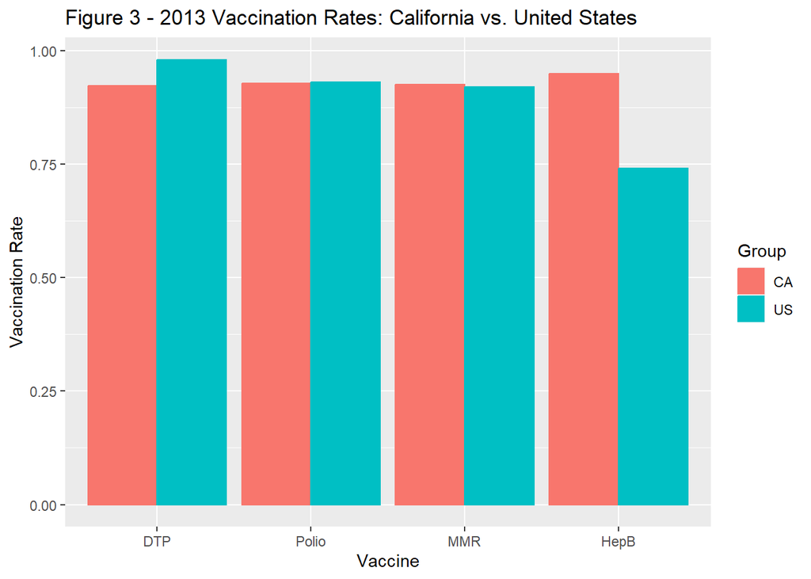

```r
# From the data frame outlined above, we can see the rates for individual vaccines as well as how those rates compared to the overall US vaccination rates for those same vaccines.  Overall, in 2013, California schools were below the US average vaccination rate for DTP and Polio, but were above the US average in MMR and HepB.

# Note:  I know that the question stated to make an 'informal' comparison to the time series, but I believe that this provides a clearer picture, as it directly compares both groups' rates during the same year.

# throw in bar chart that shows US2013 vs. US2017

dfA_2 <- dfA %>%
  gather(Group, Perc, -vaccs) %>%
  mutate(vaccs = factor(vaccs, levels = c("DTP", "Polio", "MMR", "HepB"))) %>%
  arrange(vaccs)

ggplot(data = dfA_2) +
  geom_bar(aes(x = vaccs,
               y = Perc,
               fill = Group,
               color = Group),
           stat = 'identity',
           position = position_dodge()) +
  xlab("Vaccine") +
  ylab("Vaccination Rate") +
  ggtitle("Figure 3 - 2013 Vaccination Rates: California vs. United States")
```

## 4.

Among districts, how are the vaccination rates for individual vaccines related? In other words, if students are missing one vaccine are they missing all of the others?

```r
library(car)

cor(districts[, 2:6])
```

```
##              WithoutDTP WithoutPolio WithoutMMR WithoutHepB PctUpToDate
## WithoutDTP    1.0000000    0.9814507  0.9768910   0.8882872  -0.9579712
## WithoutPolio  0.9814507    1.0000000  0.9649482   0.9034700  -0.9379057
## WithoutMMR    0.9768910    0.9649482  1.0000000   0.8901950  -0.9660567
## WithoutHepB   0.8882872    0.9034700  0.8901950   1.0000000  -0.8401573
## PctUpToDate  -0.9579712   -0.9379057 -0.9660567  -0.8401573   1.0000000
```

```r
# I do not believe that you can answer this question with just the vaccination data; from the correlation table above, we can infer that if a student does not have a particular vaccine, the `PctUpToDate` rate will go down, but we cannot infer if they are missing all the other vaccines.
```

# Predictive Analyses:

## 5.

What variables predict whether or not a district’s reporting was complete?

```r
library(MCMCpack)
library(car)

model_freq1 <- glm(DistrictComplete ~ PctChildPoverty + PctFreeMeal + PctFamilyPoverty + Enrolled + TotalSchools, family = binomial(), data = districts)
summary(model_freq1)
```

```
##
## Call:
## glm(formula = DistrictComplete ~ PctChildPoverty + PctFreeMeal +
##     PctFamilyPoverty + Enrolled + TotalSchools, family = binomial(),
##     data = districts)
##
## Deviance Residuals:
##     Min       1Q   Median       3Q      Max
## -2.7150   0.2449   0.2906   0.3453   2.2196
##
## Coefficients:
##                    Estimate Std. Error z value Pr(>|z|)
## (Intercept)       3.7482926  0.4658069   8.047 8.49e-16 ***
## PctChildPoverty   0.0316670  0.0307557   1.030  0.30318
## PctFreeMeal      -0.0151321  0.0109138  -1.387  0.16559
## PctFamilyPoverty -0.0463240  0.0393528  -1.177  0.23914
## Enrolled          0.0020846  0.0006752   3.088  0.00202 **
## TotalSchools     -0.2057911  0.0586442  -3.509  0.00045 ***
## ---
## Signif. codes:  0 '***' 0.001 '**' 0.01 '*' 0.05 '.' 0.1 ' ' 1
##
## (Dispersion parameter for binomial family taken to be 1)
##
##     Null deviance: 312.23  on 699  degrees of freedom
## Residual deviance: 275.24  on 694  degrees of freedom
## AIC: 287.24
##
## Number of Fisher Scoring iterations: 6
```

```r
exp(coef(model_freq1))
```

```
##      (Intercept)  PctChildPoverty      PctFreeMeal PctFamilyPoverty
##       42.4485444        1.0321737        0.9849818        0.9547326
##         Enrolled     TotalSchools
##        1.0020868        0.8140031
```

```r
districts_coded <- districts
districts_coded$DistrictComplete <- as.numeric(districts_coded$DistrictComplete)
bayesLogitOut1 <- MCMClogit(DistrictComplete ~ PctChildPoverty + PctFreeMeal + PctFamilyPoverty + Enrolled + TotalSchools, data = districts)
summary(bayesLogitOut1)
```

```
##
## Iterations = 1001:11000
## Thinning interval = 1
## Number of chains = 1
## Sample size per chain = 10000
##
## 1. Empirical mean and standard deviation for each variable,
##    plus standard error of the mean:
##
##                       Mean        SD  Naive SE Time-series SE
## (Intercept)       3.845247 0.4724504 4.725e-03      2.192e-02
## PctChildPoverty   0.032902 0.0299910 2.999e-04      1.260e-03
## PctFreeMeal      -0.016486 0.0112275 1.123e-04      5.324e-04
## PctFamilyPoverty -0.042661 0.0381210 3.812e-04      1.641e-03
## Enrolled          0.001983 0.0006675 6.675e-06      3.125e-05
## TotalSchools     -0.203987 0.0575777 5.758e-04      2.667e-03
##
## 2. Quantiles for each variable:
##
##                        2.5%      25%       50%       75%     97.5%
## (Intercept)       3.0065194  3.50982  3.837319  4.148345  4.802438
## PctChildPoverty  -0.0264963  0.01198  0.032249  0.053767  0.090266
## PctFreeMeal      -0.0395247 -0.02350 -0.016122 -0.008658  0.004959
## PctFamilyPoverty -0.1155588 -0.06849 -0.043158 -0.016236  0.032901
## Enrolled          0.0007247  0.00155  0.001979  0.002420  0.003325
## TotalSchools     -0.3200432 -0.24284 -0.201360 -0.163749 -0.096838
```

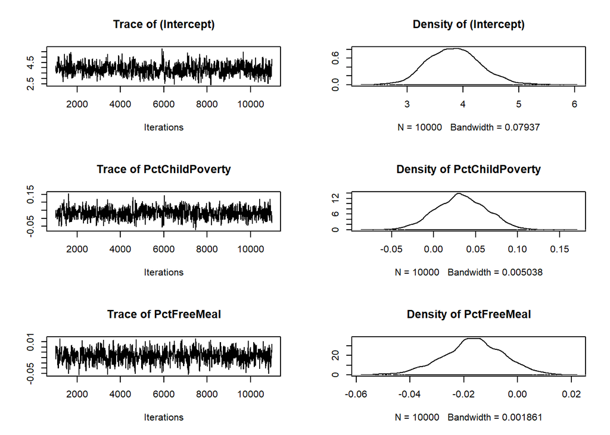

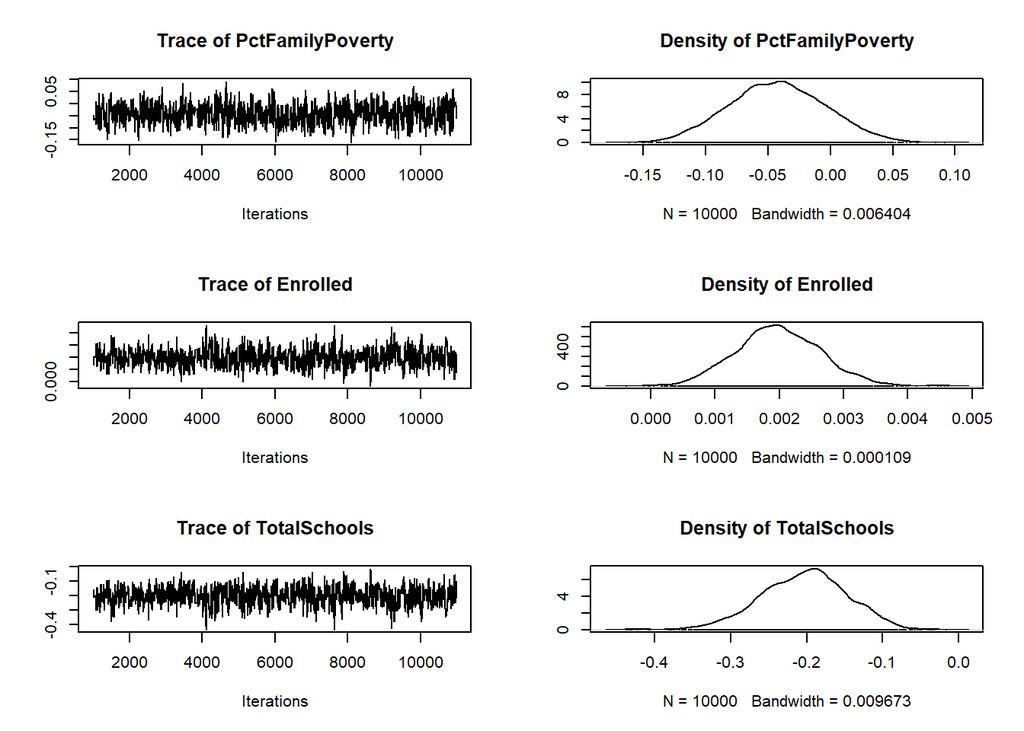

```r
plot(bayesLogitOut1)
```

```r
# According to the frequentist AND Bayesian model summaries above, we can infer that the number of students enrolled positively impacts, and total number of schools in the district negatively impacts whether or not that district completes its vaccination reporting.
```

```r
vif(model_freq1)
```

```
##  PctChildPoverty      PctFreeMeal PctFamilyPoverty         Enrolled
##         4.563251         2.224929         4.053677        47.932829
##     TotalSchools
##        47.941231
```

```r
# Using vif() to test for multicolinearity, the two most promising variables (`Enrolled` and `TotalSchools`) show very significant collinearity.  Which means that we cannot reliably use the results of their regression coefficients.
```

## 6.

What variables predict the percentage of all enrolled students with completely up-to-date vaccines?

```r
library(BayesFactor)
set.seed(123)

# Frequentist Approach
# --------------------

model_freq2 <- glm(PctUpToDate ~ PctChildPoverty + PctFreeMeal + PctFamilyPoverty + Enrolled + TotalSchools, data = districts)
summary(model_freq2)
```

```
##
## Call:
## glm(formula = PctUpToDate ~ PctChildPoverty + PctFreeMeal + PctFamilyPoverty +
##     Enrolled + TotalSchools, data = districts)
##
## Deviance Residuals:
##     Min       1Q   Median       3Q      Max
## -67.110   -3.520    3.195    7.305   18.449
##
## Coefficients:
##                   Estimate Std. Error t value Pr(>|t|)
## (Intercept)      82.045848   1.086699  75.500  < 2e-16 ***
## PctChildPoverty  -0.078131   0.078780  -0.992  0.32166
## PctFreeMeal       0.086926   0.028756   3.023  0.00260 **
## PctFamilyPoverty  0.284422   0.112909   2.519  0.01199 *
## Enrolled          0.005684   0.002016   2.819  0.00495 **
## TotalSchools     -0.504669   0.185808  -2.716  0.00677 **
## ---
## Signif. codes:  0 '***' 0.001 '**' 0.01 '*' 0.05 '.' 0.1 ' ' 1
##
## (Dispersion parameter for gaussian family taken to be 147.948)
##
##     Null deviance: 112056  on 699  degrees of freedom
## Residual deviance: 102676  on 694  degrees of freedom
## AIC: 5492.3
##
## Number of Fisher Scoring iterations: 2
```

```r
exp(coef(model_freq2))
```

```
##      (Intercept)  PctChildPoverty      PctFreeMeal PctFamilyPoverty
##     4.286066e+35     9.248428e-01     1.090816e+00     1.328994e+00
##         Enrolled     TotalSchools
##     1.005700e+00     6.037055e-01
```

```r
vif(model_freq2)
```

```
##  PctChildPoverty      PctFreeMeal PctFamilyPoverty         Enrolled
##         4.129013         2.356096         3.802240        94.616839
##     TotalSchools
##        94.554679
```

```r
# Bayesian Approach
# -----------------

model_bayes2 <- lmBF(PctUpToDate ~ PctChildPoverty + PctFreeMeal + PctFamilyPoverty + Enrolled + TotalSchools
                     , data = districts
                     , posterior = T
                     , iterations = 10000)
summary(model_bayes2)
```

```
##
## Iterations = 1:10000
## Thinning interval = 1
## Number of chains = 1
## Sample size per chain = 10000
##
## 1. Empirical mean and standard deviation for each variable,
##    plus standard error of the mean:
##
##                        Mean       SD  Naive SE Time-series SE
## mu                87.547585 0.465768 4.658e-03      4.910e-03
## PctChildPoverty   -0.075670 0.076944 7.694e-04      7.694e-04
## PctFreeMeal        0.083928 0.028583 2.858e-04      2.902e-04
## PctFamilyPoverty   0.273218 0.111097 1.111e-03      1.111e-03
## Enrolled           0.005468 0.001981 1.981e-05      1.981e-05
## TotalSchools      -0.485406 0.182707 1.827e-03      1.827e-03
## sig2             147.914444 7.994762 7.995e-02      7.995e-02
## g                  0.053864 0.055230 5.523e-04      5.523e-04
##
## 2. Quantiles for each variable:
##
##                        2.5%        25%        50%        75%      97.5%
## mu                86.628449  87.233039  87.549264  87.861309  88.459604
## PctChildPoverty   -0.227448  -0.127149  -0.075212  -0.023591   0.076801
## PctFreeMeal        0.027811   0.064960   0.083643   0.102641   0.139335
## PctFamilyPoverty   0.057166   0.199376   0.272392   0.349593   0.491927
## Enrolled           0.001578   0.004142   0.005494   0.006794   0.009362
## TotalSchools      -0.842483  -0.606385  -0.488663  -0.362634  -0.128166
## sig2             132.967509 142.347014 147.753720 153.029279 164.507628
## g                  0.014644   0.027240   0.040138   0.062247   0.171420
```

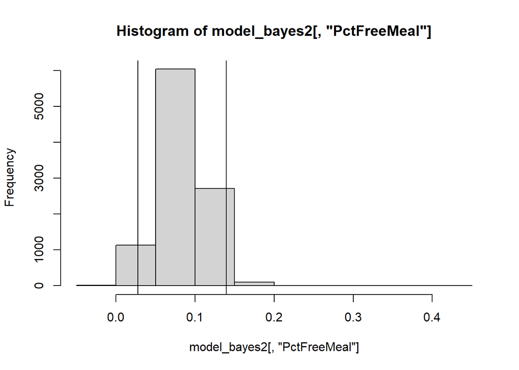

```r
# hist() of promising variables from Bayesian approach

hist(model_bayes2[, 'PctFreeMeal'])
abline(v = quantile(model_bayes2[, 'PctFreeMeal'], c(0.025)), col='black')
abline(v = quantile(model_bayes2[, 'PctFreeMeal'], c(0.975)), col='black')
```

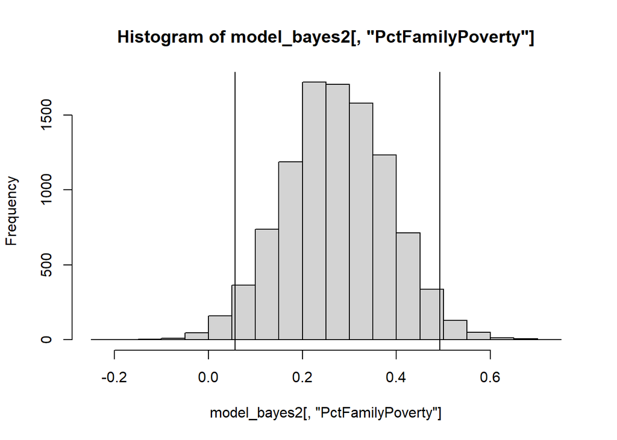

```r
hist(model_bayes2[, 'PctFamilyPoverty'])
abline(v = quantile(model_bayes2[, 'PctFamilyPoverty'], c(0.025)), col='black')
abline(v = quantile(model_bayes2[, 'PctFamilyPoverty'], c(0.975)), col='black')
```